# Data Analysis on Activity Monitoring Device using Machine Learning Algorithm

Ajay Manikandan Sankanran

July 7, 2017

## Introduction

Using devices such as Jawbone Up, Nike FuelBand, and Fitbit is now possible to collect a large amount of data about personal activity relatively inexpensively. These type of devices are part of the quantified self movement - a group of enthusiasts who take measurements about themselves regularly to improve their health, to find patterns in their behavior, or because they are tech geeks. One thing that people regularly do is quantify how much of a particular activity they do, but they rarely quantify how well they do it.

In this analysis, we will use data from accelerometers on belt, forearm, arm, dumbell of 6 participants. They were asked to perform barbell lifts correctly and incorrectly in 5 different ways. The five ways are exactly according to the specification (Class A), throwing the elbows to the front (Class B), lifting the dumbbell only halfway (Class C), lowering the dumbbell only halfway (Class D) and throwing the hips to the front (Class E). Only Class A corresponds to correct performance. The goal of this project is to predict the manner in which they did the exercise, i.e., Class A to E. More information is available from the website here: http://groupware.les.inf.puc-rio.br/har.

## Data Processing

### Importing data

We first load te R packages needed to perform the data analysis.

```r
setwd("C:/Users/Ajay Manikandan/Desktop/Coursera/R programming/Machine learning")
library(caret); library(rattle); library(rpart); library(rpart.plot); library(randomForest); library(repmis)
```

Now we download the testing and training dataset from the above mentioned website and save it in your working directory.

```r
#import the data from the URLs
#trainurl <- "https://d396qusza40orc.cloudfront.net/predmachlearn/pml-training.csv"
#testurl <- "https://d396qusza40orc.cloudfront.net/predmachlearn/pml-testing.csv"
#training <- source_data(trainurl, na.strings = c("NA", "#DIV/0!", ""), header = TRUE)
#testing <- source_data(testurl, na.strings = c("NA", "#DIV/0!", ""), header = TRUE)
#Load the dataset from the directory
training <- read.csv("pml-training.csv", na.strings = c("NA", ""))
testing <- read.csv("pml-testing.csv", na.strings = c("NA", ""))
str(training)
```

```
## 'data.frame':    19622 obs. of  160 variables:
##  $ X                       : int  1 2 3 4 5 6 7 8 9 10 ...
##  $ user_name               : Factor w/ 6 levels "adelmo","carlitos",..: 2 2 2 2 2 2 2 2 2 2 ...
##  $ raw_timestamp_part_1    : int  1323084231 1323084231 1323084231 1323084232 1323084232 1323084232 1323084232 1323084232 1323084232 1323084232 ...
##  $ raw_timestamp_part_2    : int  788290 808298 820366 120339 196328 304277 368296 440390 484323 484434 ...
##  $ cvtd_timestamp          : Factor w/ 20 levels "02/12/2011 13:32",..: 9 9 9 9 9 9 9 9 9 9 ...
##  $ new_window              : Factor w/ 2 levels "no","yes": 1 1 1 1 1 1 1 1 1 1 ...
##  $ num_window              : int  11 11 11 12 12 12 12 12 12 12 ...
##  $ roll_belt               : num  1.41 1.41 1.42 1.48 1.48 1.45 1.42 1.42 1.43 1.45 ...
##  $ pitch_belt              : num  8.07 8.07 8.07 8.05 8.07 8.06 8.09 8.13 8.16 8.17 ...
##  $ yaw_belt                : num  -94.4 -94.4 -94.4 -94.4 -94.4 -94.4 -94.4 -94.4 -94.4 -94.4 ...
##  $ total_accel_belt        : int  3 3 3 3 3 3 3 3 3 3 ...
##  $ kurtosis_roll_belt      : Factor w/ 396 levels "-0.016850","-0.021024",..: NA NA NA NA NA NA NA NA NA NA ...
##  $ kurtosis_picth_belt     : Factor w/ 316 levels "-0.021887","-0.060755",..: NA NA NA NA NA NA NA NA NA NA ...
##  $ kurtosis_yaw_belt       : Factor w/ 1 level "#DIV/0!": NA NA NA NA NA NA NA NA NA NA ...
```

[output cut: 86 more lines]

We can see that by using the `str` function the training dataset has 19622 observations and 160 variables, and the testing dataset contains 20 observations and 160 variables. We use this datasets to predict the outcome of `classe`

### Data Cleaning

We can see that the dataset contains a lot of NA values which is not useful for our analysis. Therefore, we are going to clean the dataset by removing the NA values.

```r
training <- training[, colSums(is.na(training)) == 0]
testing <- testing[, colSums(is.na(testing)) == 0]
```

We also remove the first 7 variables as they are of no revelance to the analysis.

```r
Datatrain <- training[, -c(1:7)]
Datatest <- testing[, -c(1:7)]
```

After cleaning the data we are able to see that there are only 53 variables that are required for our analysis.

### Data splitting

We split the training dataset for training and validation purpose. For reproducibility we set see

```r
set.seed(1234)
intrain <- createDataPartition(Datatrain$classe, p = 0.7, list = FALSE)
train_new <- Datatrain[intrain, ]
valid_new <- Datatrain[-intrain, ]
```

## Prediction Algorithms

We are going to use decision trees, random forest and generalized boosted regression(gbm)

### Decision trees

We are going to use 5-fold cross validation when implementing the algorithm.

```r
control <- trainControl(method = "cv", number = 5)
fit_dt <- train(classe ~ . , data = train_new, method = "rpart",
                trControl = control)
print(fit_dt, digits = 4)
```

```
## CART
##
## 13737 samples
##    52 predictor
##     5 classes: 'A', 'B', 'C', 'D', 'E'
##
## No pre-processing
## Resampling: Cross-Validated (5 fold)
## Summary of sample sizes: 10990, 10988, 10991, 10990, 10989
## Resampling results across tuning parameters:
##
##   cp       Accuracy  Kappa
##   0.03550  0.5214    0.38010
##   0.06093  0.4175    0.21094
##   0.11738  0.3333    0.07467
##
## Accuracy was used to select the optimal model using  the largest value.
## The final value used for the model was cp = 0.0355.
```

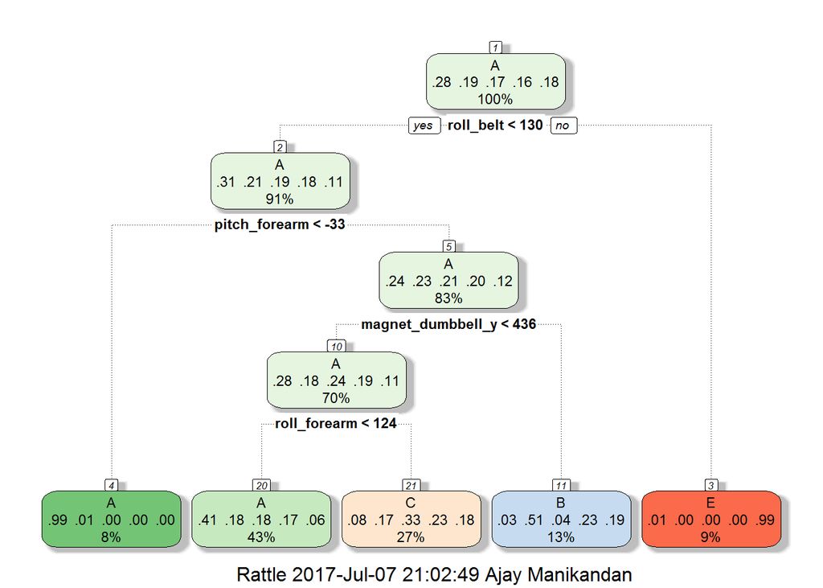

```r
fancyRpartPlot(fit_dt$finalModel)
```

```r
#predicting outcomes using validation dataset
pred_dt <- predict(fit_dt, valid_new)
#Prediction result
(conf_dt <- confusionMatrix(valid_new$classe, pred_dt))
```

```
## Confusion Matrix and Statistics
##
##           Reference
## Prediction    A    B    C    D    E
##          A 1530   35  105    0    4
##          B  486  379  274    0    0
##          C  493   31  502    0    0
##          D  452  164  348    0    0
##          E  168  145  302    0  467
##
## Overall Statistics
##
##                Accuracy : 0.489
##                  95% CI : (0.4762, 0.5019)
##     No Information Rate : 0.5317
##     P-Value [Acc > NIR] : 1
##
##                   Kappa : 0.3311
##  Mcnemar's Test P-Value : NA
##
## Statistics by Class:
##
##                      Class: A Class: B Class: C Class: D Class: E
## Sensitivity            0.4890   0.5027   0.3279       NA  0.99151
## Specificity            0.9478   0.8519   0.8797   0.8362  0.88641
## Pos Pred Value         0.9140   0.3327   0.4893       NA  0.43161
## Neg Pred Value         0.6203   0.9210   0.7882       NA  0.99917
## Prevalence             0.5317   0.1281   0.2602   0.0000  0.08003
## Detection Rate         0.2600   0.0644   0.0853   0.0000  0.07935
## Detection Prevalence   0.2845   0.1935   0.1743   0.1638  0.18386
## Balanced Accuracy      0.7184   0.6773   0.6038       NA  0.93896
```

```r
(accuracy_dt <- conf_dt$overall[1])
```

```
##  Accuracy
## 0.4890399
```

From the above confusion matrix we can see that predicting using decision trees yeilds a accuracy rate of 0.48 which is very low.

### Random Forest

Random forest machine learning algorithm is implemented.

```r
fit_rf <- train(classe ~., data = train_new, method = "rf",
                trControl = control)
print(fit_rf, digits = 4)
```

```
## Random Forest
##
## 13737 samples
##    52 predictor
##     5 classes: 'A', 'B', 'C', 'D', 'E'
##
## No pre-processing
## Resampling: Cross-Validated (5 fold)
## Summary of sample sizes: 10991, 10989, 10989, 10990, 10989
## Resampling results across tuning parameters:
##
##   mtry  Accuracy  Kappa
##    2    0.9913    0.9889
##   27    0.9919    0.9898
##   52    0.9876    0.9843
##
## Accuracy was used to select the optimal model using  the largest value.
## The final value used for the model was mtry = 27.
```

```r
# Prediction of outcomes using validation dataset
pred_rf <- predict(fit_rf, valid_new)
(conf_rf <- confusionMatrix(valid_new$classe, pred_rf))
```

```
## Confusion Matrix and Statistics
##
##           Reference
## Prediction    A    B    C    D    E
##          A 1674    0    0    0    0
##          B   12 1126    1    0    0
##          C    0    3 1019    4    0
##          D    0    1    5  957    1
##          E    0    1    2    3 1076
##
## Overall Statistics
##
##                Accuracy : 0.9944
##                  95% CI : (0.9921, 0.9961)
##     No Information Rate : 0.2865
##     P-Value [Acc > NIR] : < 2.2e-16
##
##                   Kappa : 0.9929
##  Mcnemar's Test P-Value : NA
##
## Statistics by Class:
##
##                      Class: A Class: B Class: C Class: D Class: E
## Sensitivity            0.9929   0.9956   0.9922   0.9927   0.9991
## Specificity            1.0000   0.9973   0.9986   0.9986   0.9988
## Pos Pred Value         1.0000   0.9886   0.9932   0.9927   0.9945
## Neg Pred Value         0.9972   0.9989   0.9984   0.9986   0.9998
## Prevalence             0.2865   0.1922   0.1745   0.1638   0.1830
## Detection Rate         0.2845   0.1913   0.1732   0.1626   0.1828
## Detection Prevalence   0.2845   0.1935   0.1743   0.1638   0.1839
## Balanced Accuracy      0.9964   0.9964   0.9954   0.9957   0.9989
```

```r
(accuracy_rf <- conf_rf$overall[1])
```

```
##  Accuracy
## 0.9943925
```

### Generalized boosted regression

```r
fit_gbm <- train(classe ~., data = train_new, method = "gbm",
                 trControl = control, verbose = FALSE)
pred_gbm <- predict(fit_gbm, valid_new)
(conf_gbm <- confusionMatrix(valid_new$classe, pred_gbm))
```

```
## Confusion Matrix and Statistics
##
##           Reference
## Prediction    A    B    C    D    E
##          A 1652   13    3    5    1
##          B   35 1072   27    5    0
##          C    0   32  979   12    3
##          D    0    6   26  924    8
##          E    1    9   15   14 1043
##
## Overall Statistics
##
##                Accuracy : 0.9635
##                  95% CI : (0.9584, 0.9681)
##     No Information Rate : 0.2868
##     P-Value [Acc > NIR] : < 2.2e-16
##
##                   Kappa : 0.9538
##  Mcnemar's Test P-Value : 6.385e-06
##
## Statistics by Class:
##
##                      Class: A Class: B Class: C Class: D Class: E
## Sensitivity            0.9787   0.9470   0.9324   0.9625   0.9886
## Specificity            0.9948   0.9859   0.9903   0.9919   0.9919
## Pos Pred Value         0.9869   0.9412   0.9542   0.9585   0.9640
## Neg Pred Value         0.9915   0.9874   0.9854   0.9927   0.9975
## Prevalence             0.2868   0.1924   0.1784   0.1631   0.1793
## Detection Rate         0.2807   0.1822   0.1664   0.1570   0.1772
## Detection Prevalence   0.2845   0.1935   0.1743   0.1638   0.1839
## Balanced Accuracy      0.9867   0.9665   0.9613   0.9772   0.9903
```

```r
(accuracy_gbm <- conf_gbm$overall[1])
```

```
##  Accuracy
## 0.9634664
```

## Prediction on test dataset

```r
(predict(fit_rf, testing))
```

```
##  [1] B A B A A E D B A A B C B A E E A B B B
## Levels: A B C D E
```